# ENCE - C Implementation Test

In the directory `elastic_net_C_implementation`, I implemented my own version of `glmnet` (elastic net regressor) written in C (this will allow me to use OpenMP later). This document runs a very rough and quick accuracy and timing comparison between the original `glmnet`-based ENCE and the C version

## Setup

Load the simulated data, source the C library glue, and subset to a small problem.

```r
source("idw.R")
source("elastic_net_C_implementation/elastic_net_R_glue.R")

n_stations <- 50
n_months   <- 60

rain <- read.csv("simulated_rainfall.csv")
rain <- rain[rain$stno <= n_stations & rain$t <= n_months, ]   # small subset for now
```

## Imputation

Mask 25% of the data uniformly at random and run both variants from the same starting point.

```r
df_miss <- rain
set.seed(313)
sample_rows <- sort(sample(nrow(df_miss), nrow(df_miss) * 0.25))
df_miss[sample_rows, "y"] <- NA
```

Run the original `glmnet`-based ENCE first, then the C-backed version on the same masked data.

```r
source("ENCE_glmnet.R")
time_glmnet <- system.time({
  imp_glmnet <- ENCE(df_miss, response = "y", max_cycles = 30,
                     init_method = "idw",
                     x_name = "east", y_name = "north", t_name = "t",
                     C = 15000,
                     transformation = sqrt,
                     reverse_transformation = function(x) x^2,
                     truth = rain$y, masked_idx = sample_rows)
})
ext_rmse_glmnet <- attr(imp_glmnet, "ext_rmse_history")
```

```r
source("ENCE_myelasticnet.R")
time_c <- system.time({
  imp_c <- ENCE(df_miss, response = "y", max_cycles = 30,
                init_method = "idw",
                x_name = "east", y_name = "north", t_name = "t",
                C = 15000,
                transformation = sqrt,
                reverse_transformation = function(x) x^2,
                truth = rain$y, masked_idx = sample_rows)
})
ext_rmse_c <- attr(imp_c, "ext_rmse_history")
```

## Results

### Timing

```r
cat("glmnet version:   ", round(time_glmnet["elapsed"], 2), "seconds\n")
```

```
## glmnet version:    18.66 seconds
```

```r
cat("C version:        ", round(time_c["elapsed"], 2),       "seconds\n")
```

```
## C version:         10.74 seconds
```

```r
cat("Ratio (C/glmnet): ", round(time_c["elapsed"] / time_glmnet["elapsed"], 2), "\n")
```

```
## Ratio (C/glmnet):  0.58
```

### Accuracy against truth

Final external RMSE (predicted vs. true rainfall at the masked locations):

```r
cat("glmnet final ext_rmse: ", round(tail(ext_rmse_glmnet, 1), 4), "\n")
```

```
## glmnet final ext_rmse:  18.225
```

```r
cat("C      final ext_rmse: ", round(tail(ext_rmse_c, 1), 4),       "\n")
```

```
## C      final ext_rmse:  17.9893
```

Per-cycle external RMSE trajectory:

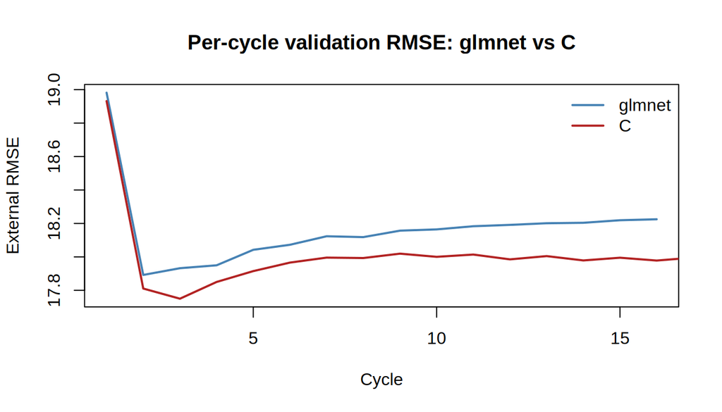

```r
plot(ext_rmse_glmnet, type = "l", col = "steelblue", lwd = 2,
     xlab = "Cycle", ylab = "External RMSE",
     main = "Per-cycle validation RMSE: glmnet vs C",
     ylim = range(c(ext_rmse_glmnet, ext_rmse_c)))
lines(ext_rmse_c, col = "firebrick", lwd = 2)
legend("topright", legend = c("glmnet", "C"),
       col = c("steelblue", "firebrick"), lty = 1, lwd = 2, bty = "n")
```

### Agreement between the two implementations

```r
imp_diff_rmse <- sqrt(mean((imp_glmnet[sample_rows, "y"] -
                            imp_c[sample_rows, "y"])^2))
cat("RMSE between glmnet and C imputations at masked rows:",
    round(imp_diff_rmse, 4), "\n")
```

```
## RMSE between glmnet and C imputations at masked rows: NA
```